# Telco Churn Prediction

Notre Dame Data Club

## **1. Exploratory Data Analysis**

### **1.1 Load Packages**

```r
library(doParallel) #multicore processing
library(glmnet) #lasso
library(ggplot2) #ploting
library(forecast)
library(caret) #ml package
library(dplyr)
library(OptimalCutpoints)  #best cut point
library(xgboost) #xgboost
library(splitstackshape) #data partition
library(naniar)#find missing value
library(DMwR)#SMOTE
library(xgboostExplainer) # Load XGboost Explainer
library(pROC) # Load proc
library(randomForest)
library(fastDummies)
```

### **1.2Load the data**

```r
load("churn_data.rda") #Load the data
```

**CustomerID**: A unique ID that identifies each customer.

**Gender**: The customer’s gender: Male, Female

**Age**: The customer’s current age, in years, at the time the fiscal quarter ended.

**Senior Citizen**: Indicates if the customer is 65 or older: Yes, No

**Dependents**: Indicates if the customer lives with any dependents: Yes, No. Dependents could be children, parents, grandparents, etc.

**City**: The city of the customer’s primary residence.

**Monthly Charge**: Indicates the customer’s current total monthly charge for all their services from the company.

**Number of Referrals**: Indicates the number of referrals to date that the customer has made.

**Population**: A current population estimate for the entire Zip Code area.

**Tenure in Months**: Indicates the total amount of months that the customer has been with the company by the end of the quarter specified above.

**Contract**: Indicates the customer’s current contract type: Month-to-Month, One Year, Two Year.

**Churn Value**: 1 = the customer left the company this quarter. 0 = the customer remained with the company. Directly related to Churn Label.

**CLTV**: Customer Lifetime Value. A predicted CLTV is calculated using corporate formulas and existing data. The higher the value, the more valuable the customer. High value customers should be monitored for churn.

**Satisfaction Score**: A customer’s overall satisfaction rating of the company from 1 (Very Unsatisfied) to 5 (Very Satisfied).

**Churn Score**: A value from 0-100 that is calculated using the predictive tool IBM SPSS Modeler. The model incorporates multiple factors known to cause churn. The higher the score, the more likely the customer will churn.

### **1.3Data information and cheat variables**

```
## [1] 7043   54
```

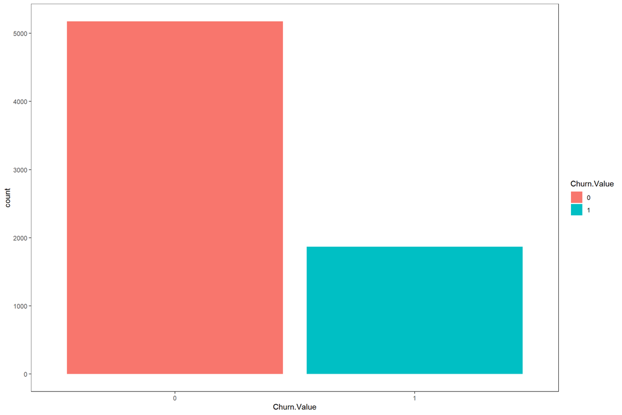

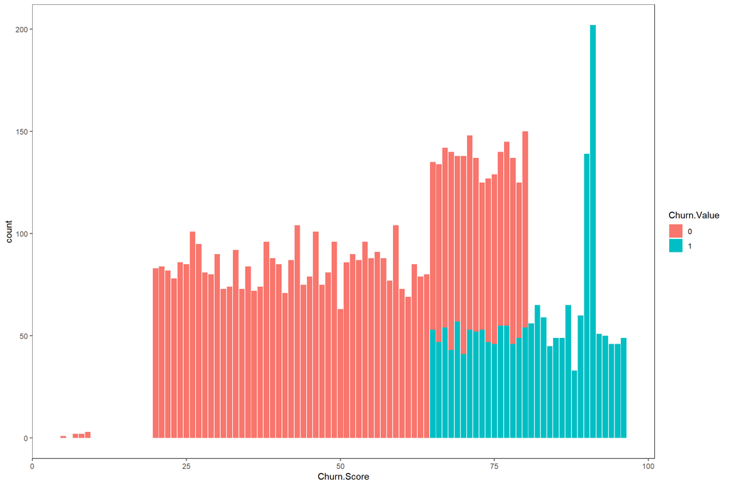

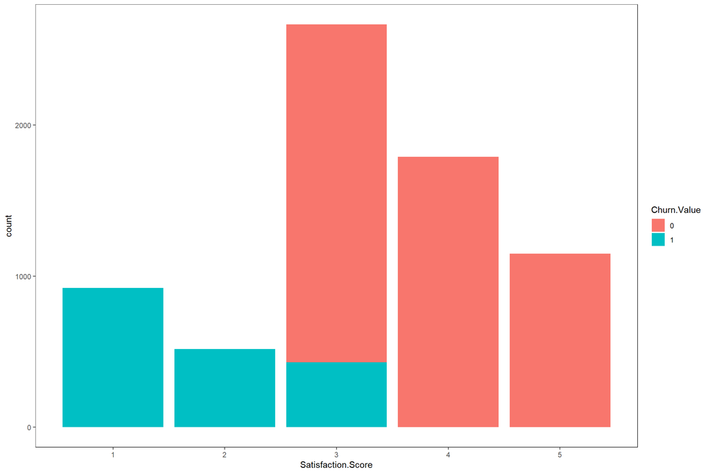

### **1.4Data pre-processing**

```r
churn_data$Zip.Code <- as.factor(churn_data$Zip.Code) #zip code is should be a factor, but we are going to use them anyway....
total_data <- cbind.data.frame(churn_value = churn_data$Churn.Value,churn_data[,-c(1,2,10,11,13,14,17,18,19,20,21,22,24,25,26)]) # move the churn.value to the first row
indx <- which(unlist(summarise_each(total_data, funs(class)) =='character')) #select the character columns
for (i in indx){
  total_data[,i] <- gsub(" ", "_",total_data[,i])
  total_data[,i] <- gsub("-", "_",total_data[,i])#need to replace the space and hyphen to underscore, it will smooth the later scaling process
}
```

### **RandomForest Important Variables**

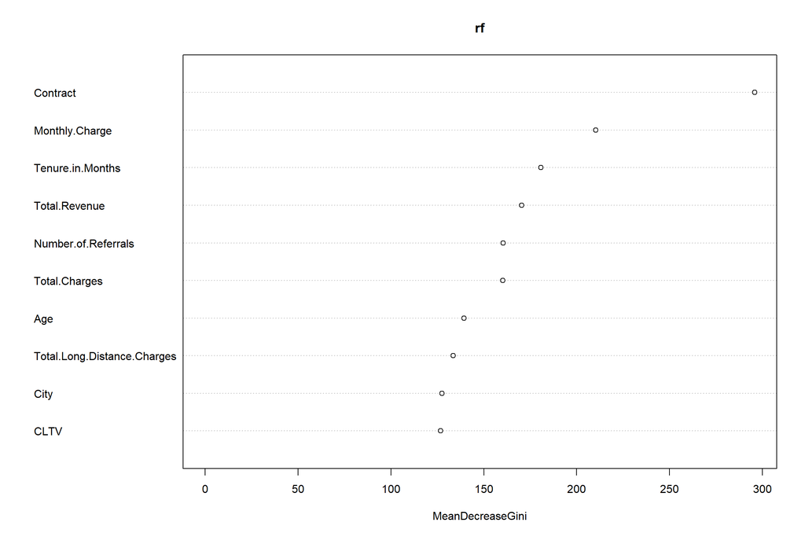

### **Consumer Distribution**

[figure not shown]

### **Contract**

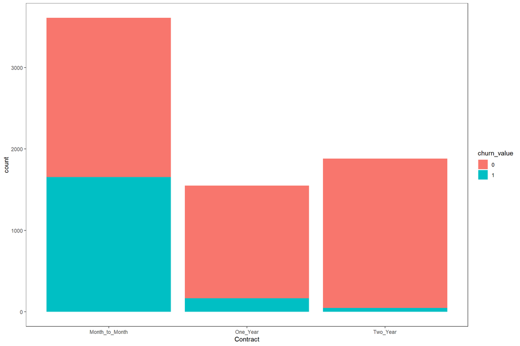

### **Monthly Charge**

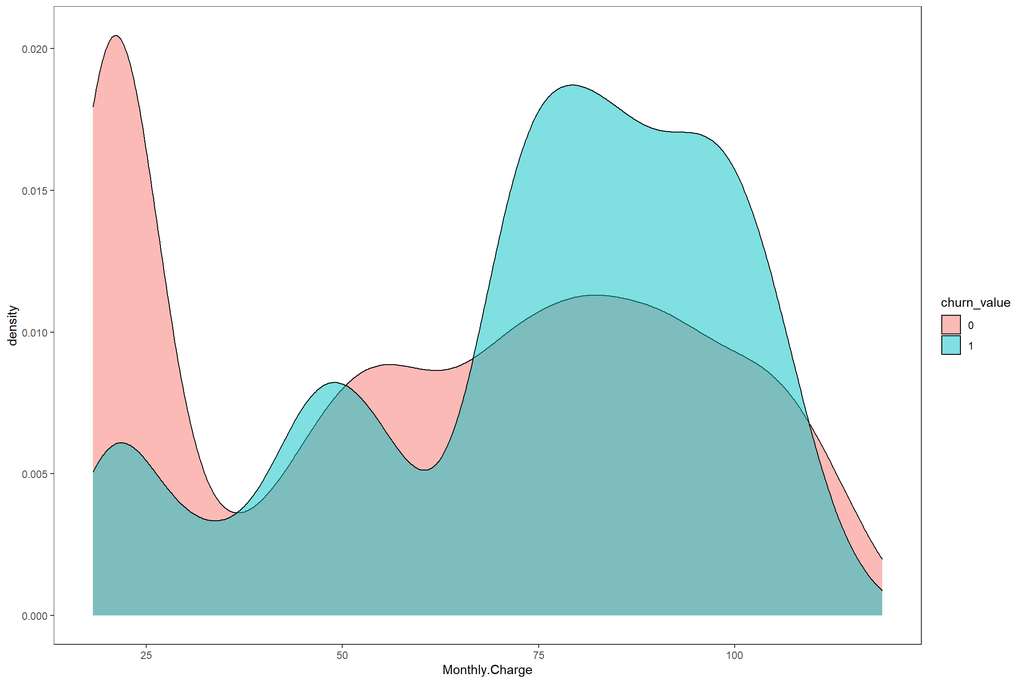

### **Tenure in Months**

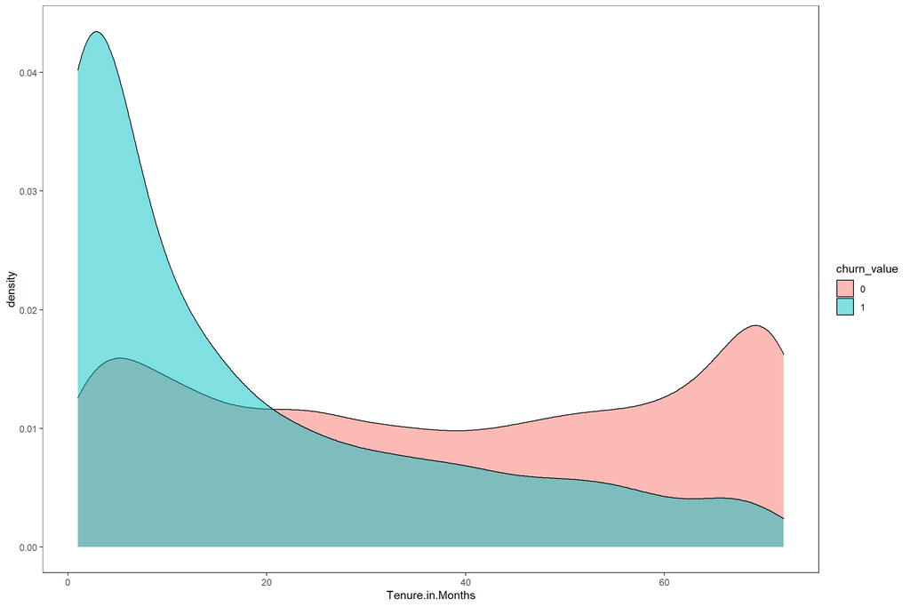

### **Number of Referrals**

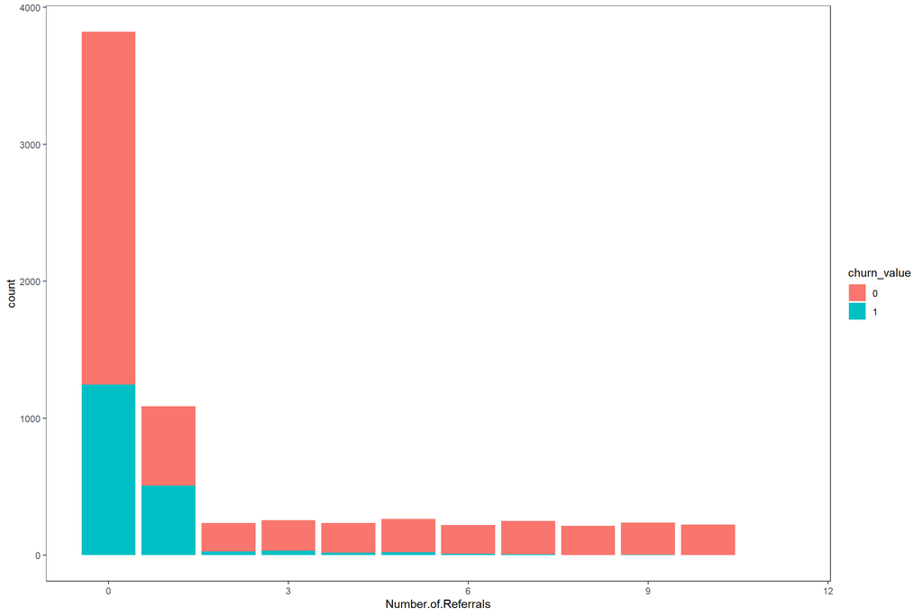

### **City**

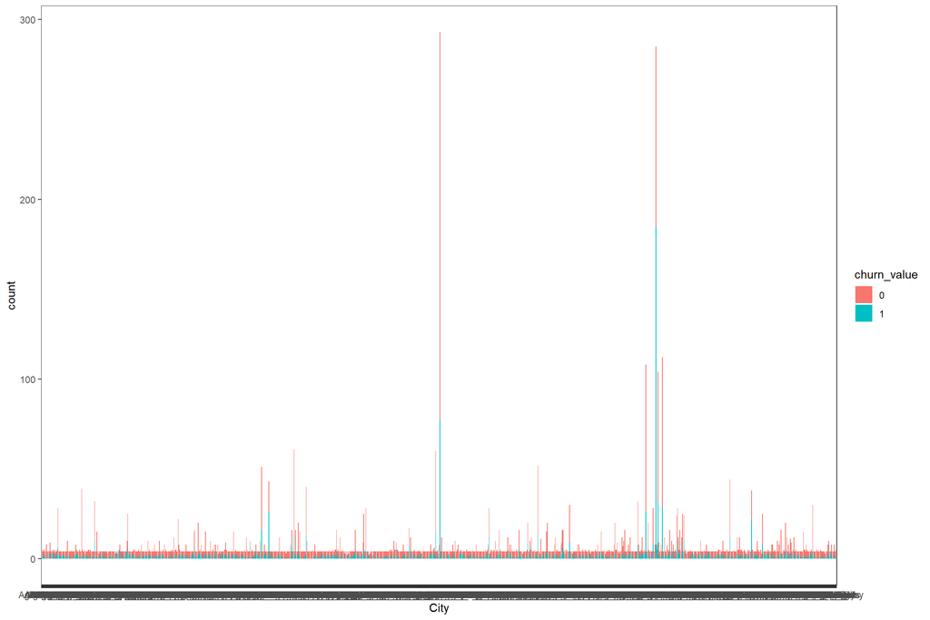

### **Top 7 Cities**

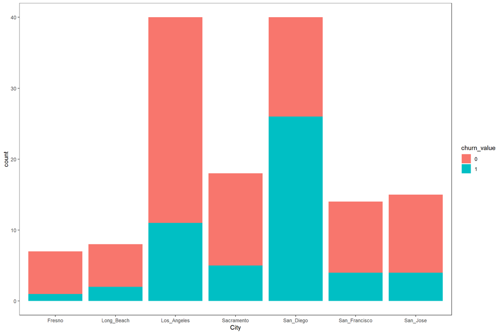

### **Age**

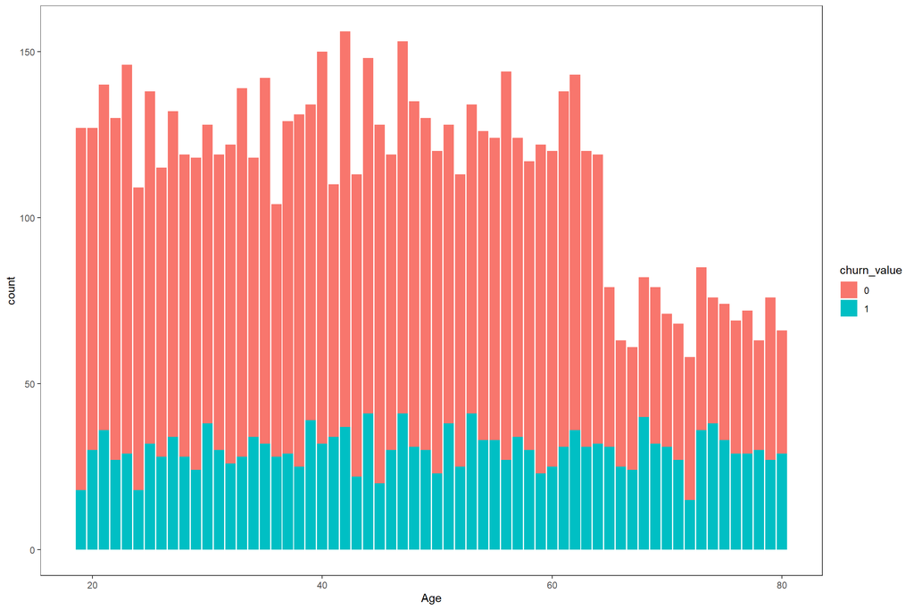

### **Senior-City**

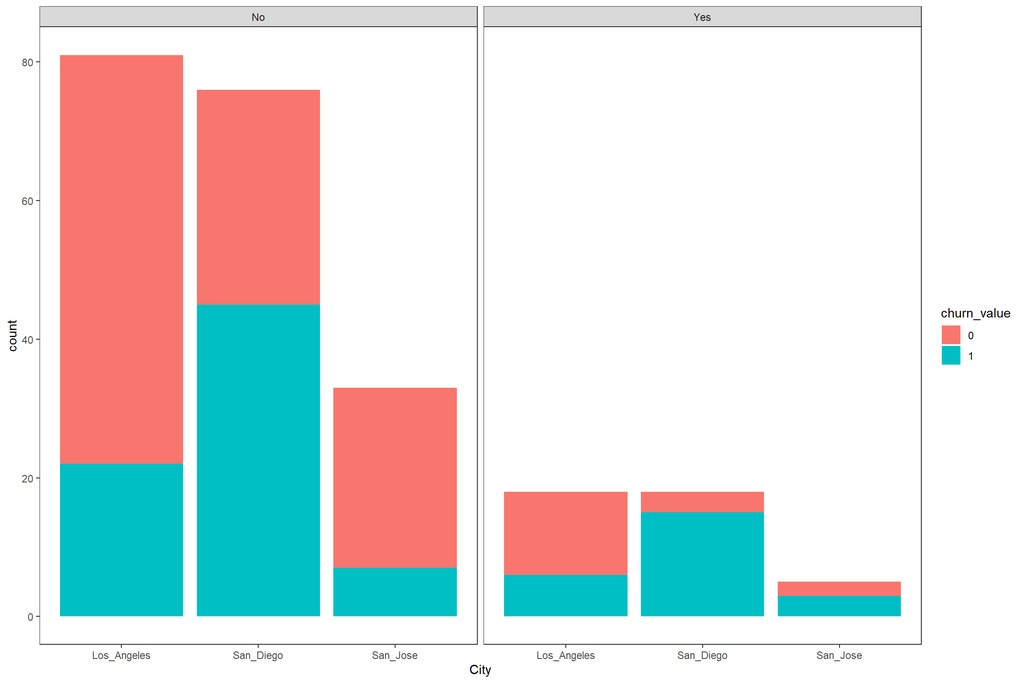

### **Population Density**

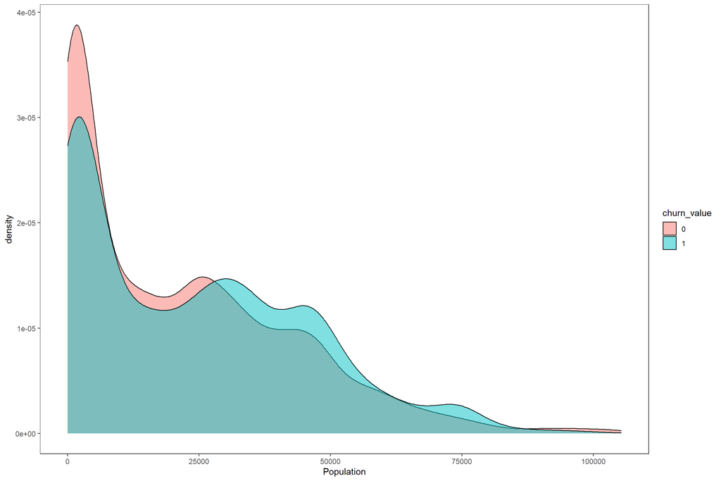

### **Senior-Contract**

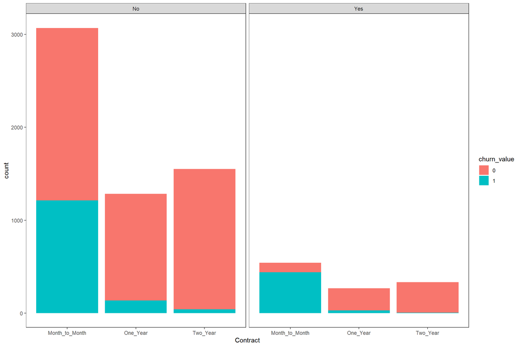

## **2. Machine learning modeling**

### **2.1 Data Scaling and Dummy Variables**

```r
total_data <- total_data %>% select(-Longitude,-Latitude)
scaledata <- dummy_cols(total_data[,-1],remove_selected_columns = T)
scaledata <- scale(scaledata)
scaledata <- cbind.data.frame(churn_value= total_data$churn_value,scaledata)
dim(scaledata)
```

```
## [1] 7043 1173
```

### **2.2 Lasso Regression**

#### **2.2.1 Find the Best lambda for the data set**

```r
set.seed(1)
temp_lasso <- stratified(scaledata, group = "churn_value", size = 0.8,bothSets = T)
lasso_train <- temp_lasso[[1]]
lasso_test <- data.matrix(temp_lasso[[2]])
lasso_test[,1] <-lasso_test[,1]-1

doParallel::registerDoParallel(cores = 6)
x_vars <- as.matrix(lasso_train[,-1])
lambda_seq <- 10^seq(4, -4, by = -.1)
cv.lasso <- cv.glmnet(x = x_vars,
                      y = lasso_train$churn_value,
                      alpha = 1,
                      family = "binomial",
                      lambda = lambda_seq,
                      parallel = T,
                      nfolds = 10)
best_lam <- cv.lasso$lambda.1se

lambda_seq <- seq(best_lam-0.004,best_lam+0.005,0.0001)# reduce the testing range

cv.lasso <- cv.glmnet(x = x_vars,
                      y = lasso_train$churn_value,
                      alpha = 1,
                      family = "binomial",
                      lambda = lambda_seq,
                      parallel = T,
                      nfolds = 10)
best_lam <- cv.lasso$lambda.1se
best_lam
```

```
## [1] 0.0118
```

```r
best_lasso <- glmnet(x = x_vars,
                     y = lasso_train$churn_value,
                     alpha = 1,
                     family = "binomial",
                     lambda = best_lam)


lasso_coef <- as.data.frame(as.matrix(coef(best_lasso))) %>% filter(s0 != 0)
lasso_coef_list <- c("churn_value",row.names(lasso_coef)[-1])
```

#### **2.2.2 Fitting the lasso Regression model**

```r
x_vars <- lasso_train[,-1]
best_lasso1 <- glmnet(x = x_vars,
                     y = as.factor(lasso_train$churn_value),
                     alpha = 1,
                     family = "binomial",
                     type.measure="class",
                     lambda = best_lam)
```

#### **2.2.3 Predicting and find the best Cutoff Point**

```r
lasso_pred <- predict(best_lasso1, lasso_test[,-1], type = "response")
df_pred <- cbind.data.frame(response = lasso_test[,1],prediction = lasso_pred[,1])
oc<- optimal.cutpoints(X = "prediction",
                       status = "response",
                       tag.healthy = 0,
                       data = df_pred,
                       methods = "MaxEfficiency")

best_cut_off <- oc$MaxEfficiency$Global$optimal.cutoff$cutoff[1]
best_cut_off
```

```
## [1] 0.5162621
```

#### **2.2.4 Lasso Regression Confusion Matrix**

```r
lasso_result <- ifelse(lasso_pred > best_cut_off, 1, 0)
t <- table(prediction = lasso_result[,1],response = lasso_test[,1])
confusionMatrix(t, positive = "1")
```

```
## Confusion Matrix and Statistics
##
##           response
## prediction   0   1
##          0 965 147
##          1  70 227
##
##                Accuracy : 0.846
##                  95% CI : (0.8261, 0.8645)
##     No Information Rate : 0.7346
##     P-Value [Acc > NIR] : < 2.2e-16
##
##                   Kappa : 0.5773
##
##  Mcnemar's Test P-Value : 2.48e-07
##
##             Sensitivity : 0.6070
##             Specificity : 0.9324
##          Pos Pred Value : 0.7643
##          Neg Pred Value : 0.8678
##              Prevalence : 0.2654
##          Detection Rate : 0.1611
##    Detection Prevalence : 0.2108
##       Balanced Accuracy : 0.7697
##
##        'Positive' Class : 1
##
```

### **2.3 Xgboost**

#### **2.3.1 Xgboost data preparation**

```r
xgb_total <- dummy_columns(total_data[,-1],remove_selected_columns = T)
xgb_total <- cbind.data.frame(churn_value= total_data$churn_value,xgb_total)
xgb_total <- xgb_total[,lasso_coef_list]


set.seed(1)
temp <- stratified(as.data.frame(xgb_total), group = "churn_value", size = .8, bothSets = T)
xgb_prep <- data.matrix(temp[[1]])
xgb_prep[,1] <- xgb_prep[,1]-1
xgb_prep1 <- data.matrix(temp[[2]])
xgb_prep1[,1] <- xgb_prep1[,1]-1

xgb_train <- xgb.DMatrix(data = xgb_prep[,-1], label = xgb_prep[,1] )
xgb_test <- xgb.DMatrix(data = xgb_prep1[,-1], label = xgb_prep1[,1] )

xgb_prep <- data.frame(temp[[1]])
xgb_prep1 <- data.frame(temp[[2]])
```

#### **2.3.2 Fitting the Xgboost Model(w/o tuning)**

```r
set.seed(1)
bst <- xgboost(data = xgb_train, # Set training data
               eta = 0.1, # Set learning rate
               nrounds = 2000, # Set number of rounds
               early_stopping_rounds = 50, # Set number of rounds to stop at
               verbose = 0, # 1 - Prints out fit
               nthread = 6, # Set number of parallel threads

               objective = "binary:logistic", # Set objective
               eval_metric = "auc",
               eval_metric = "error")
xgb_pred <- predict(bst, xgb_test)
pred_dat <- cbind.data.frame(prediction = xgb_pred , response = xgb_prep1$churn_value)


oc<- optimal.cutpoints(X = "prediction",
                       status = "response",
                       tag.healthy = 0,
                       data = pred_dat,
                       methods = "MaxEfficiency")

best_cut_off <- oc$MaxEfficiency$Global$optimal.cutoff$cutoff
result <- ifelse(xgb_pred > best_cut_off, 1, 0)
t <- table(prediction = result,response = xgb_prep1$churn_value)
confusionMatrix(t, positive = "1")
```

```
## Confusion Matrix and Statistics
##
##           response
## prediction   0   1
##          0 934 122
##          1 101 252
##
##                Accuracy : 0.8417
##                  95% CI : (0.8216, 0.8604)
##     No Information Rate : 0.7346
##     P-Value [Acc > NIR] : <2e-16
##
##                   Kappa : 0.5867
##
##  Mcnemar's Test P-Value : 0.1805
##
##             Sensitivity : 0.6738
##             Specificity : 0.9024
##          Pos Pred Value : 0.7139
##          Neg Pred Value : 0.8845
##              Prevalence : 0.2654
##          Detection Rate : 0.1789
##    Detection Prevalence : 0.2505
##       Balanced Accuracy : 0.7881
##
##        'Positive' Class : 1
##
```

#### **2.3.3 Xgboost Model(w/o tuning) vs Lasso Regression**

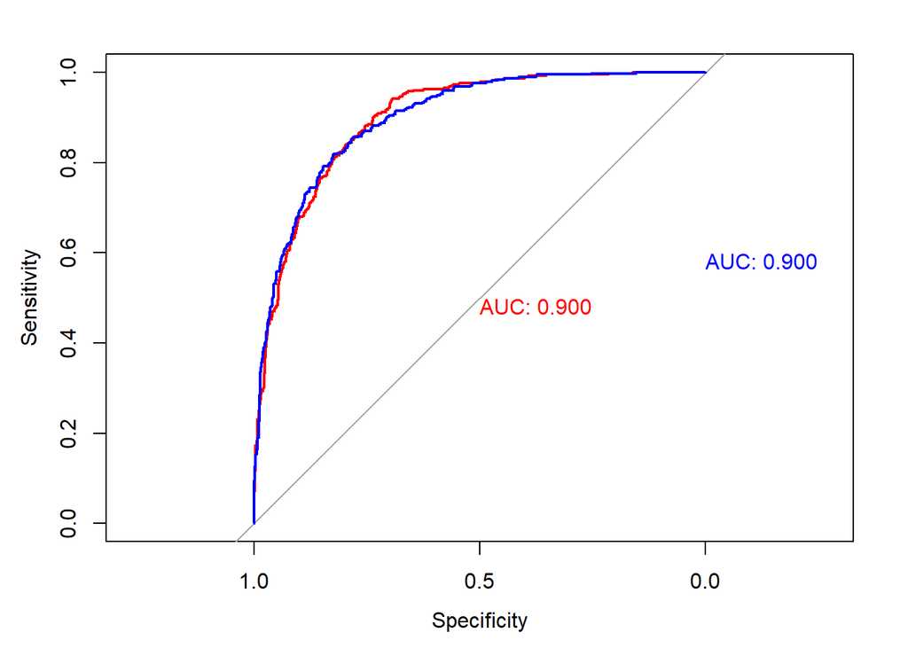

```r
plot.roc(xgb_roc, print.auc = TRUE, col = "red", print.auc.col = "red")
plot.roc(lasso_roc, print.auc = TRUE, print.auc.x = 0, print.auc.y = 0.6, col ="blue", print.auc.col = "blue", add = TRUE)
```

### **2.4 Xgboost Tuning**

#### **2.4.1 Xgboost tuning preparation**

```r
grid_search <- expand.grid(
  max_depth_list = c(2,3,4,5,6),
  min_child_weight = c(0,1,2,4,5),
  gamma_list = c(0.4),
  subsample = c(1), # Create vector of subsample values
  colsample_by_tree = c(0.7) # Create vector of col sample
)
auc_vec <- error_vec <- rep(NA, nrow(grid_search))
```

#### **2.4.2 Xgboost Gridsearch Cross Validation**

```r
for (i in 1:nrow(grid_search)){
  set.seed(1)
  bst.tune <- xgb.cv(data = xgb_train,
                     eta = 0.1, # Set learning rate
                     nrounds = 1000, # Set number of rounds
                     early_stopping_rounds = 100, # Set number of rounds to stop at
                     verbose = 0, # 1 - Prints out fit
                     nthread = 6, # Set number of parallel threads

                     max.depth = grid_search$max_depth_list[i],
                     min_child_weight = grid_search$min_child_weight[i],
                     gamma = grid_search$gamma_list[i],
                     subsample = grid_search$subsample[i],
                     colsample_by_tree = grid_search$colsample_by_tree[i],

                     nfold = 5,
                     objective = "binary:logistic", # Set objective
                     eval_metric = "auc",
                     eval_metric = "error")
  auc_vec[i] <- bst.tune$evaluation_log$test_auc_mean[bst.tune$best_ntreelimit]
  error_vec[i] <- bst.tune$evaluation_log$test_error_mean[bst.tune$best_ntreelimit]
}
res_db <- cbind.data.frame(grid_search, auc = auc_vec, error = error_vec)
res_db$max_depth_list <- as.factor(res_db$max_depth_list)
res_db$min_child_weight <- as.factor(res_db$min_child_weight)
```

#### **2.4.3 Gridsearch Visualization**

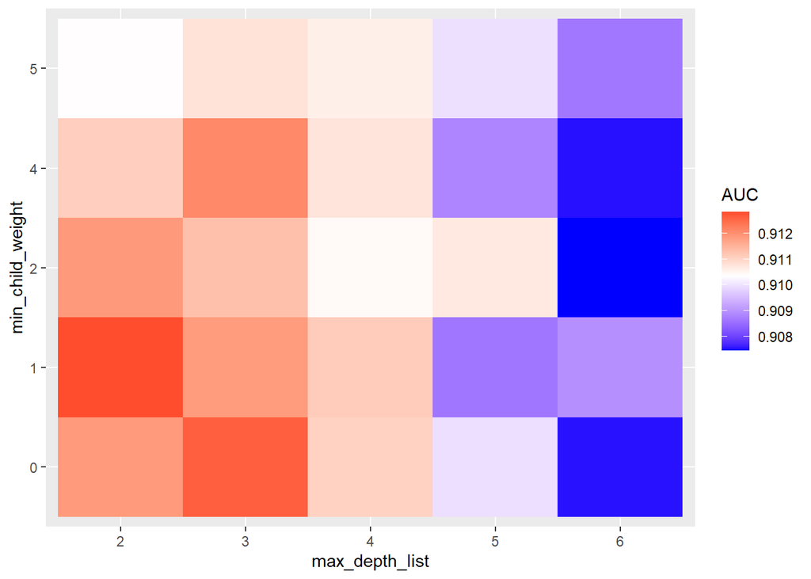

```r
ggplot(res_db, aes(x = max_depth_list, y = min_child_weight, fill = auc))+ geom_tile()+ scale_fill_gradient2(low = "blue", "AUC",high = "red", midpoint =mean(res_db$auc))
```

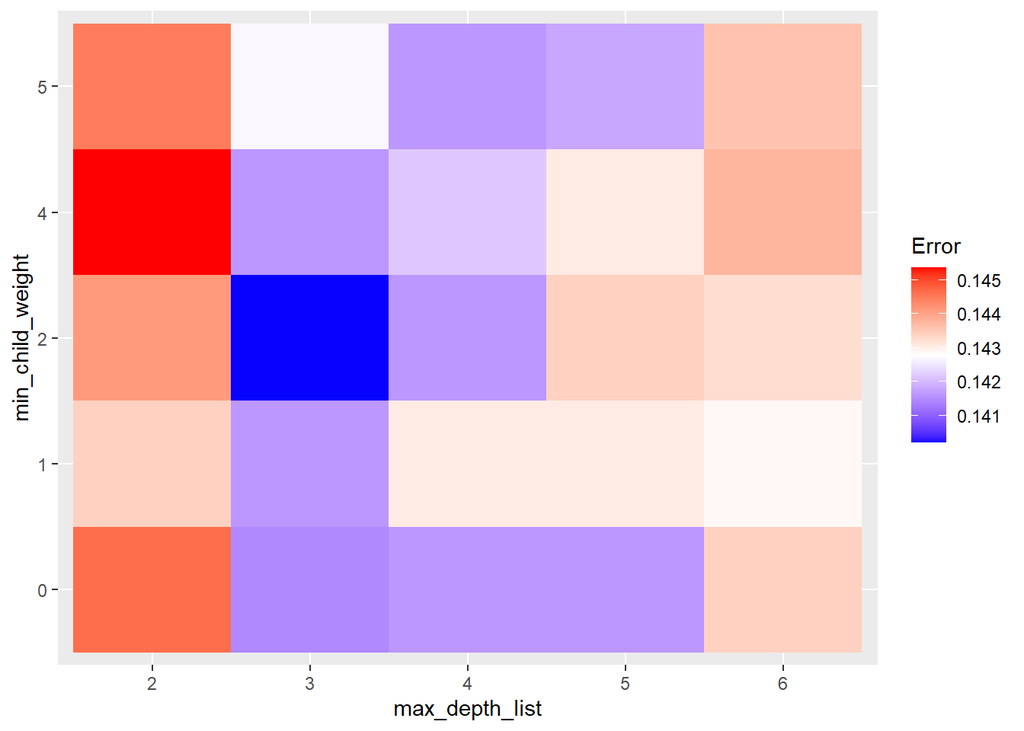

```r
ggplot(res_db, aes(x = max_depth_list, y = min_child_weight, fill = error))+ geom_tile()+scale_fill_gradient2(low = "blue", "Error",high = "red", midpoint =mean(res_db$error))
```

#### **2.4.4 Xgboost ETA tuning**

```r
eta_tuning <- function(eta_val){
set.seed(1)
bst_eta <- xgb.cv(data = xgb_train, # Set training data
                     nfold = 5, # Use 5 fold cross-validation
                     eta = eta_val, # Set learning rate
                     max.depth = 3,
                     min_child_weight = 0,
                     gamma = 0.4,
                     subsample = 1, # Set proportion of training data to use in tree
                     colsample_bytree = 0.7, # Set number of variables to use in each tree
                     nrounds = 20000, # Set number of rounds
                     early_stopping_rounds = 1000, # Set number of rounds to stop at if there is no improvement
                     verbose = 0, # 1 - Prints out fit
                     nthread = 6, # Set number of parallel threads
                     objective = "binary:logistic", # Set objective
                     eval_metric = "auc",
                     eval_metric = "error") # Set evaluation metric to use
}

eta_0.005 <- eta_tuning(0.005)
eta_0.01 <- eta_tuning(0.01)
eta_0.05 <- eta_tuning(0.05)
eta_0.1 <- eta_tuning(0.1)
eta_0.3 <- eta_tuning(0.3)

pd1 <- cbind.data.frame(eta_0.005$evaluation_log[,c("iter", "test_error_mean")], rep(0.005, nrow(eta_0.005$evaluation_log)))
names(pd1)[c(1,2,3)] <- c("iter","error","eta")
pd2 <- cbind.data.frame(eta_0.01$evaluation_log[,c("iter", "test_error_mean")], rep(0.01, nrow(eta_0.01$evaluation_log)))
names(pd2)[c(1,2,3)] <- c("iter","error","eta")
pd3 <- cbind.data.frame(eta_0.05$evaluation_log[,c("iter", "test_error_mean")], rep(0.05, nrow(eta_0.05$evaluation_log)))
names(pd3)[c(1,2,3)] <- c("iter","error","eta")
pd4 <- cbind.data.frame(eta_0.1$evaluation_log[,c("iter", "test_error_mean")], rep(0.1, nrow(eta_0.1$evaluation_log)))
names(pd4)[c(1,2,3)] <- c("iter","error","eta")
pd5 <- cbind.data.frame(eta_0.3$evaluation_log[,c("iter", "test_error_mean")], rep(0.3, nrow(eta_0.3$evaluation_log)))
names(pd5)[c(1,2,3)] <- c("iter","error","eta")
```

#### **2.4.5 Xgboost ETA Visualization**

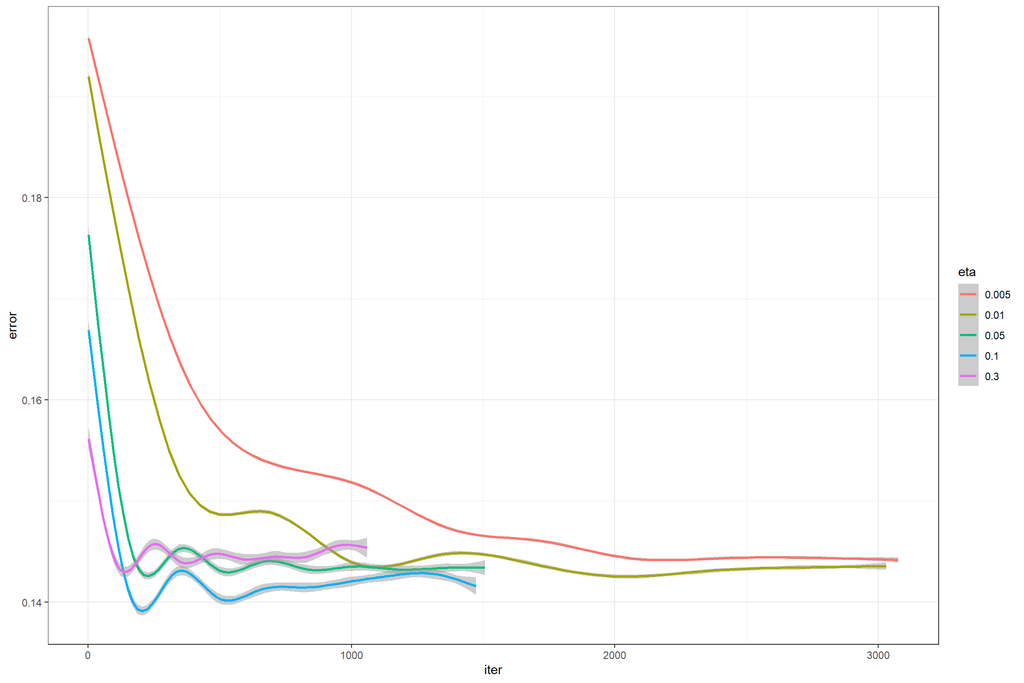

```r
plot_data <- rbind.data.frame(pd1, pd2, pd3, pd4, pd5)
plot_data$eta <- as.factor(plot_data$eta)
ggplot(plot_data, aes(x = iter, y = error, color = eta))+
  geom_smooth(method = 'gam', formula= y ~ s(x, bs = "cs"), alpha = 0.5)+
  theme_bw()
```

#### **2.4.6 Fitting the final Xgboost Model(w/ tuning)**

```r
set.seed(1)
bst <- xgboost(data = xgb_train, # Set training data
                     eta = 0.1, # Set learning rate
                     max.depth = 3,
                     min_child_weight = 0,
                     gamma = 0.4,
                     subsample = 1, # Set proportion of training data to use in tree
                     colsample_bytree = 0.7, # Set number of variables to use in each tree

                     nrounds = 480, # Set number of rounds

                     verbose = 1, # 1 - Prints out fit
                     nthread = 6, # Set number of parallel threads
                     print_every_n = 100, # Prints out result every 20th iteration

                     objective = "binary:logistic", # Set objective
                     eval_metric = "auc",
                     eval_metric = "error") # Set evaluation metric to use
xgb_pred <- predict(bst, xgb_test)
pred_dat <- cbind.data.frame(prediction = xgb_pred , response = xgb_prep1$churn_value)


oc<- optimal.cutpoints(X = "prediction",
                       status = "response",
                       tag.healthy = 0,
                       data = pred_dat,
                       methods = "MaxEfficiency")

best_cut_off <- oc$MaxEfficiency$Global$optimal.cutoff$cutoff
bst_xgb_result <- ifelse(xgb_pred > best_cut_off, 1, 0)
t <- table(prediction = bst_xgb_result,response = xgb_prep1$churn_value)
confusionMatrix(t, positive = "1")
```

```
## Confusion Matrix and Statistics
##
##           response
## prediction   0   1
##          0 938 110
##          1  97 264
##
##                Accuracy : 0.8531
##                  95% CI : (0.8335, 0.8712)
##     No Information Rate : 0.7346
##     P-Value [Acc > NIR] : <2e-16
##
##                   Kappa : 0.619
##
##  Mcnemar's Test P-Value : 0.4042
##
##             Sensitivity : 0.7059
##             Specificity : 0.9063
##          Pos Pred Value : 0.7313
##          Neg Pred Value : 0.8950
##              Prevalence : 0.2654
##          Detection Rate : 0.1874
##    Detection Prevalence : 0.2562
##       Balanced Accuracy : 0.8061
##
##        'Positive' Class : 1
##
```

#### **2.4.7 Xgboost Variable importance**

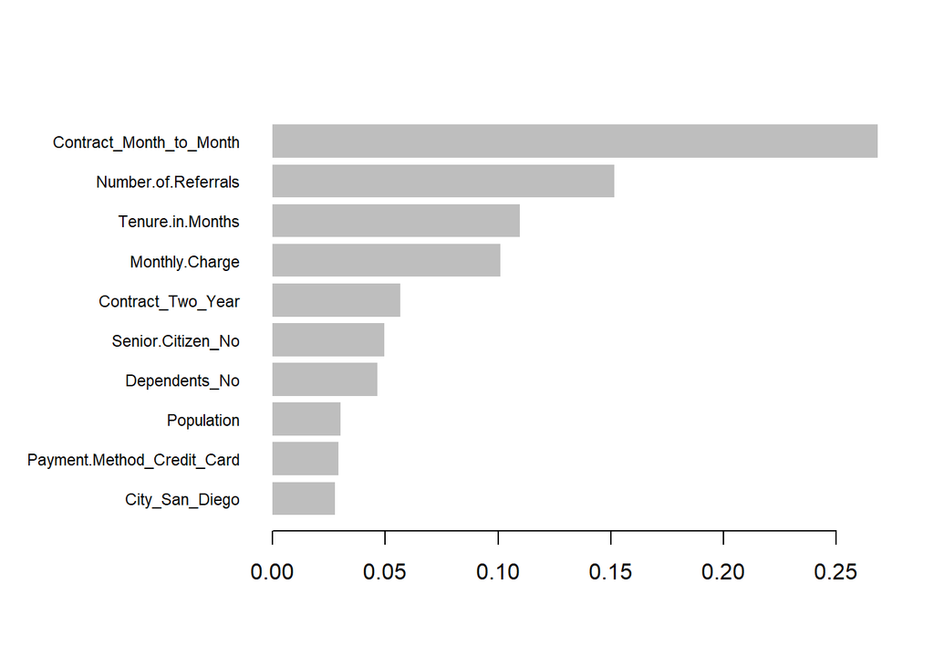

#### **2.4.8 Xgboost Model(w/ tuning) vs Lasso Regression**

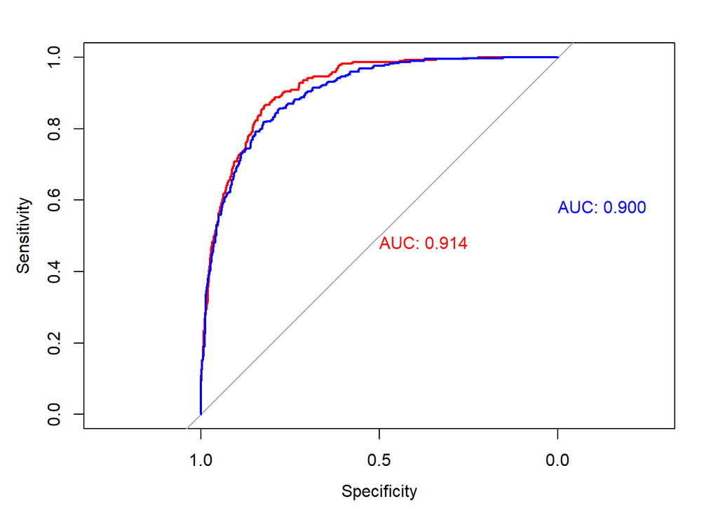

### **2.5 other Machine learning models**

#### **2.5.1 Data Processing(Normalization) for other Machine learning models**

```r
set.seed(1)
normalized_dat <- xgb_total[,lasso_coef_list][,-1]
x_mean <- apply(normalized_dat, 2, mean)
x_sd <- apply(normalized_dat, 2, sd)
normalized_dat <- scale(normalized_dat, center = x_mean, scale = x_sd) #normalize the training data
normalized_dat <- cbind.data.frame(churn_value = xgb_total$churn_value, normalized_dat)

temp_total <- stratified(normalized_dat, group = "churn_value", size = 0.8,bothSets = T)#seed 1 will make sure we always get the same partittion
train_data <- temp_total[[1]]
test_data <- temp_total[[2]]
```

#### **2.5.2 Fitting the Model(Logistic Regession, Generalized additive model, NN)**

```r
lm_full <- glm(churn_value ~.,train_data, family = "binomial")
library(gam)
gam_1 <- gam(churn_value ~ s(Number.of.Referrals) + s(Tenure.in.Months) + s(Monthly.Charge) +
    s(Population) + Senior.Citizen_No + Senior.Citizen_Yes + Dependents_No +
    Dependents_Yes + City_Acampo + City_Bakersfield + City_Camp_Nelson +
    City_Daly_City + City_Fallbrook + City_Grizzly_Flats + City_Jackson +
    City_La_Puente + City_Pearblossom + City_Riverbank + City_San_Diego +
    City_San_Dimas + City_Smith_River + City_Temecula + City_Thousand_Palms +
    City_Travis_Afb + City_Twain + City_Upland + City_Winterhaven +
    Referred.a.Friend_No + Referred.a.Friend_Yes + Offer_Offer_D +
    Offer_Offer_E + Internet.Service_No + Internet.Type_Fiber_Optic +
    Internet.Type_None + Online.Security_No + Online.Security_Yes +
    Premium.Tech.Support_No + Premium.Tech.Support_Yes + Streaming.TV_No +
    Streaming.TV_Yes + Streaming.Movies_No + Streaming.Movies_Yes +
    Streaming.Music_No + Streaming.Music_Yes + Contract_Month_to_Month +
    Contract_Two_Year + Paperless.Billing_No + Paperless.Billing_Yes +
    Payment.Method_Credit_Card + Payment.Method_Mailed_Check, train_data, family = "binomial")
set.seed(1)
nn1 <- neuralnet::neuralnet(churn_value == 1~.,train_data, linear.output = F, hidden = c(4))
```

#### **2.5.3 Prediction and confusion Matrix**

```r
lm_full_pred <- predict(lm_full, test_data, type = "response")
gam_1_pred <- predict(gam_1, test_data, type = "response")
nn1_pred <- predict(nn1, test_data)
confusionMatrix(factor(ifelse(gam_1_pred>0.5, '1', '0')), test_data$churn_value, positive = '1')
```

```
## Confusion Matrix and Statistics
##
##           Reference
## Prediction   0   1
##          0 945 128
##          1  90 246
##
##                Accuracy : 0.8453
##                  95% CI : (0.8253, 0.8638)
##     No Information Rate : 0.7346
##     P-Value [Acc > NIR] : < 2e-16
##
##                   Kappa : 0.5899
##
##  Mcnemar's Test P-Value : 0.01221
##
##             Sensitivity : 0.6578
##             Specificity : 0.9130
##          Pos Pred Value : 0.7321
##          Neg Pred Value : 0.8807
##              Prevalence : 0.2654
##          Detection Rate : 0.1746
##    Detection Prevalence : 0.2385
##       Balanced Accuracy : 0.7854
##
##        'Positive' Class : 1
##
```

```r
confusionMatrix(factor(ifelse(lm_full_pred>0.5, '1', '0')), test_data$churn_value, positive = '1')
```

```
## Confusion Matrix and Statistics
##
##           Reference
## Prediction   0   1
##          0 944 129
##          1  91 245
##
##                Accuracy : 0.8439
##                  95% CI : (0.8238, 0.8624)
##     No Information Rate : 0.7346
##     P-Value [Acc > NIR] : < 2e-16
##
##                   Kappa : 0.5862
##
##  Mcnemar's Test P-Value : 0.01261
##
##             Sensitivity : 0.6551
##             Specificity : 0.9121
##          Pos Pred Value : 0.7292
##          Neg Pred Value : 0.8798
##              Prevalence : 0.2654
##          Detection Rate : 0.1739
##    Detection Prevalence : 0.2385
##       Balanced Accuracy : 0.7836
##
##        'Positive' Class : 1
##
```

```r
confusionMatrix(factor(ifelse(nn1_pred>0.5, '1', '0')), test_data$churn_value, positive = '1')
```

```
## Confusion Matrix and Statistics
##
##           Reference
## Prediction   0   1
##          0 960 141
##          1  75 233
##
##                Accuracy : 0.8467
##                  95% CI : (0.8268, 0.8651)
##     No Information Rate : 0.7346
##     P-Value [Acc > NIR] : < 2.2e-16
##
##                   Kappa : 0.5834
##
##  Mcnemar's Test P-Value : 9.748e-06
##
##             Sensitivity : 0.6230
##             Specificity : 0.9275
##          Pos Pred Value : 0.7565
##          Neg Pred Value : 0.8719
##              Prevalence : 0.2654
##          Detection Rate : 0.1654
##    Detection Prevalence : 0.2186
##       Balanced Accuracy : 0.7753
##
##        'Positive' Class : 1
##
```

#### **2.5.4 ROC cruve and Lift Chart For all ML models**

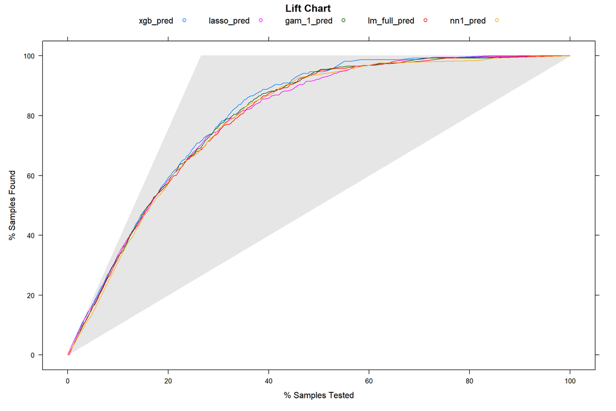

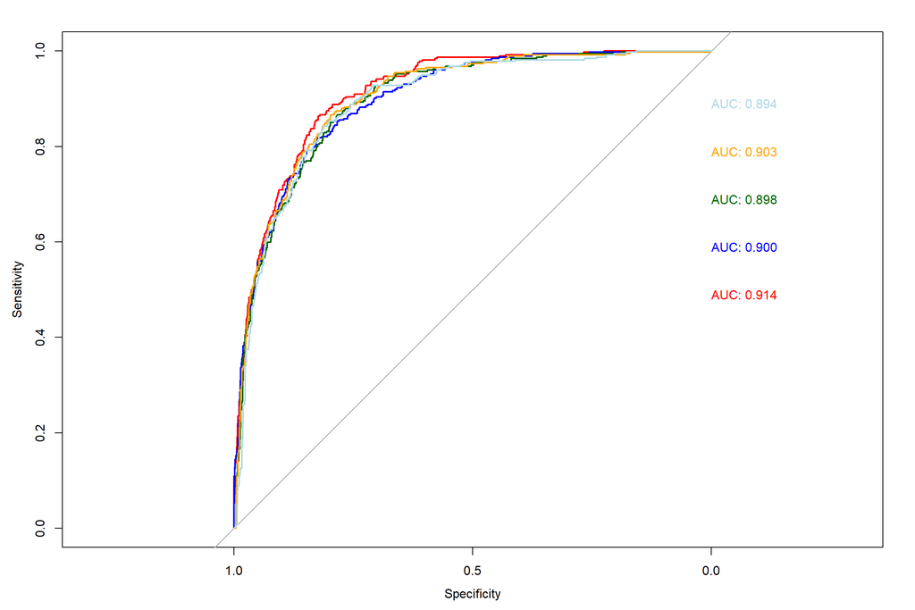

## **3. Implications for business decision making**

#### **3.1 Retention cost saving modeling**

```r
set.seed(1)
temp1 <- stratified(total_data, group = "churn_value", size = 0.8,bothSets = T)
test_cltv <- temp1[[2]]$CLTV

model_result <- function(x,Retention_rate, marketing_cost) {
  tuning <- seq(0, .7, 0.02)
  accuracy_table <- matrix(0,ncol = 6,
                           nrow = length(tuning),
                           dimnames = list(tuning, c("Accuracy","Precision","Recall(Churned)","Specificity(Stayed)","F1_score","Potential_Profit")))

  for (i in tuning) {
    Accuracy <- length(x[(x < i & test_data$churn_value == 0)|(x > i & test_data$churn_value == 1)])/length(x)
    Precision <- length(x[x > i & test_data$churn_value == 1])/length(x[x > i])
    Recall <- length(x[x > i & test_data$churn_value == 1])/length(x[test_data$churn_value == 1])
    Specificity <- length(x[x < i & test_data$churn_value == 0])/length(x[test_data$churn_value == 0])
    F1_score <-  2 * (Recall*Precision) / (Recall + Precision)
    Potential_Profit <- sum(test_cltv[x > i & test_data$churn_value == 1])*Retention_rate-length(x[x > i])*marketing_cost
    accuracy_table[rownames(accuracy_table) == i,
                   1] <- Accuracy
    accuracy_table[rownames(accuracy_table) == i,
                   2] <- Precision
    accuracy_table[rownames(accuracy_table) == i,
                   3] <- Recall
    accuracy_table[rownames(accuracy_table) == i,
                   4] <- Specificity
    accuracy_table[rownames(accuracy_table) == i,
                   5] <- F1_score
    accuracy_table[rownames(accuracy_table) == i,
                   6] <- Potential_Profit
  }
  accuracy_table
}
business_model_result <- model_result(xgb_pred, 0.15, 100)
```

#### **3.2 Cost Saving Plot**

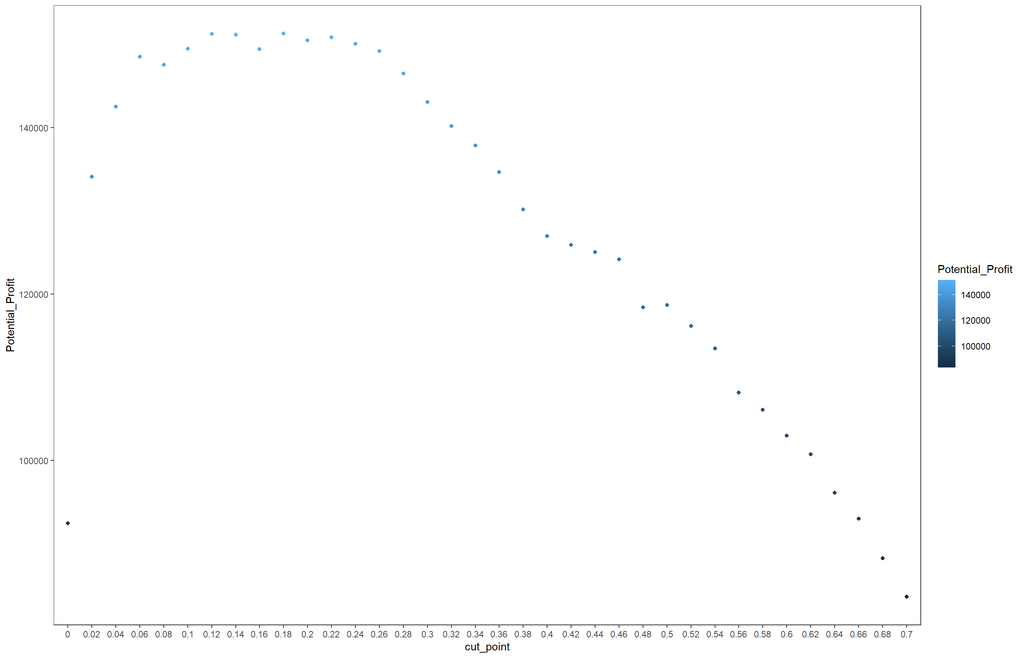

```r
business_model_result <- cbind.data.frame(cut_point = row.names(business_model_result),business_model_result)

ggplot(data = business_model_result, aes(x = cut_point, y = Potential_Profit, color = Potential_Profit))+
  geom_point()+
  theme_bw() +
  theme(panel.background = element_blank(),
        panel.grid.major = element_blank(),
        panel.grid.minor = element_blank())
```